# Beta Binomial Example

```r
knitr::opts_chunk$set(eval= TRUE)
```

```r
library("extraDistr")
library("MASS")

library(rjags)
library(parallel)
library(dclone)
library(abind)
library(R2WinBUGS)
library(RCurl)
```

This is an example of binomial survival, where we follow the fate of $n$ individuals during a single time interval. We let $X = \text{number of survivors}$ be binomially distributed:
$$f(x|p) = \binom{n}{x}p^{x}(1-p)^{n-x}$$
In the absence of previous information we may postulate that the prior distribution of $p$ is uniform:
$$g(p)=1, \quad 0\leq p \leq 1$$
Suppose $n=20$ and $x=5$. The posterior distribution is
$$h(p|x)\propto f(x|p)g(p) = \binom{n}{x}p^x(1-p)^{n-x}$$
This posterior distribution representes the belief of a Bayesian who was initially indiferent to the value of $p$ after observing 5 survivals in 20 trials. The uniform prior expresses an indiference about the possible values of $p$, which is modified after the experiment.

# Quantifying prior beliefs using a Beta distribution

If instead, we use a Beta distribution for $p$, we get:
$$g(p) \propto p^{a-1}(1-p)^{b-1}$$
and the posterior distribution of $p$ given $x$ is:
$$h(p|x)\propto f(x|p)g(p) = \binom{n}{x}p^{x}(1-p)^{n-x}p^{a-1}(1-p)^{b-1}\propto p^{a+x-1}(1-p)^{n+b-x-1}$$
which is a new beta distribution with parameters $a' = a+x$ and $b' = n+b-x$.

## Example using R

We simulate a vector of data, where survival is binomially distributed, and the probability of survival is randomly sampled from a beta distribution.

```r
n <- 30
a <- 2 #true value of a
b <- 5 # true value of b
ntrials <- 20

# We randomly sample values of p from a beta distribution using the true parameters a and b
P <- rbeta(n=n, shape1=a, shape2=b)
P
```

```
##  [1] 0.414344173 0.478563884 0.147884761 0.241730909 0.375659629 0.298066464
##  [7] 0.146713006 0.255960542 0.436271196 0.276287238 0.022602698 0.106573756
## [13] 0.176221735 0.452815355 0.470270364 0.006673155 0.324425166 0.572007933
## [19] 0.319502071 0.091433922 0.179039904 0.336550257 0.329620011 0.093429569
## [25] 0.280026474 0.283587404 0.608886852 0.133610394 0.014145795 0.162641375
```

```r
# And for each (n=30), we calculate the survival for the individuals (number of successes out of 20 trials) based on P.
YgP <- rbinom(n=n, size=ntrials, prob=P)
YgP
```

```
##  [1]  8 13  0  7  4  7  1  2 10  8  0  2  2 12  9  1  3 12  8  2  2  8  7  2  4
## [26]  4  9  6  1  5
```

Now, using the data we created, we can estimate the parameters a and b, based on the data. We should get values close to the true values of a and b, which we used to simulate the data in the first place. The following function returns the sum of the negative log likelihood for a beta binomial distribution, which we will use for getting the maximum likelihood estimators for a and b.

```r
bbnegllike <- function(guess, Yvec, ntrials=20){

  pos.guess <- exp(guess)
  a <- pos.guess[1]
  b <- pos.guess[2]

  bbnegll.vec <- dbbinom(x=Yvec, size=ntrials, alpha=a, beta=b, log=TRUE)

  return(-sum(bbnegll.vec))

}
```

```r
# Using the function described above and the sample data from Y given P
myguess <- log(c(1.5,4)) # My guess for the parameters a and b
opt.samp <- optim(par=myguess, fn=bbnegllike, method="Nelder-Mead",
                  Yvec=YgP, ntrials=ntrials)
a.hat <- exp(opt.samp$par[1])
b.hat <- exp(opt.samp$par[2])

# These are the estimates for the parameters a and b, based on the data we provided
# We can compare them to the true values we used for simulating the data
knitr::kable(data.frame(a.hat = a.hat, a = a, b.hat = b.hat, b=b))
```

| a.hat | a | b.hat | b |
| --- | --- | --- | --- |
| 1.574583 | 2 | 4.415175 | 5 |

# Using MCMC: first a Bayesian approach.

Then Data Cloning which includes the Bayesian results as a special case The first thing to do is to put together a function with the posterior calculations that needs to be sent to JAGS. This function is written in JAGS language

```r
beta.binom <- function(){

  # needs:
  # a vector of counts (Y)
  # the length of this vector (len)
  # the number of binomial trials (ntrials)

  # priors for a and b
  log.a~dnorm(mu.prior,precis.prior)
  a <- exp(log.a)

  log.b~dnorm(mu.prior,precis.prior)
  b <- exp(log.b)

  # Random effects model
  for(i in 1:len){
    Prand[i] ~ dbeta(a,b)
  }

  # Likelihood (conditioned on the random effect)
  for(i in 1:len){
    Y[i] ~ dbinom(Prand[i],ntrials)
  }

}
```

So now, using the same data that we simulated before, we use a Bayesian approach to estimate the parameters of interest.

```r
out.parms <- c("a","b", "Prand")
jags.list <- list(Y=YgP, len=n, ntrials=ntrials, mu.prior=0, precis.prior=0.00001)

bayesian.fit <- jags.fit(jags.list, params=out.parms, model=beta.binom,
                         n.chains=3, n.adapt=3000, n.update=1000, n.iter=30000, thin=10)
```

The output of the object `bayesian.fit` is a list of 3 chains. This is estimating parameters a, b, and the random P that gets drawn from the beta distribution.

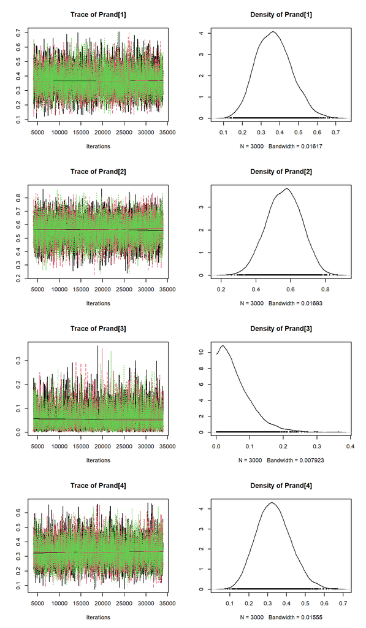

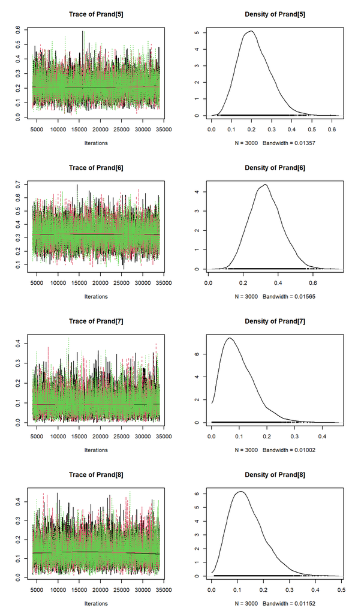

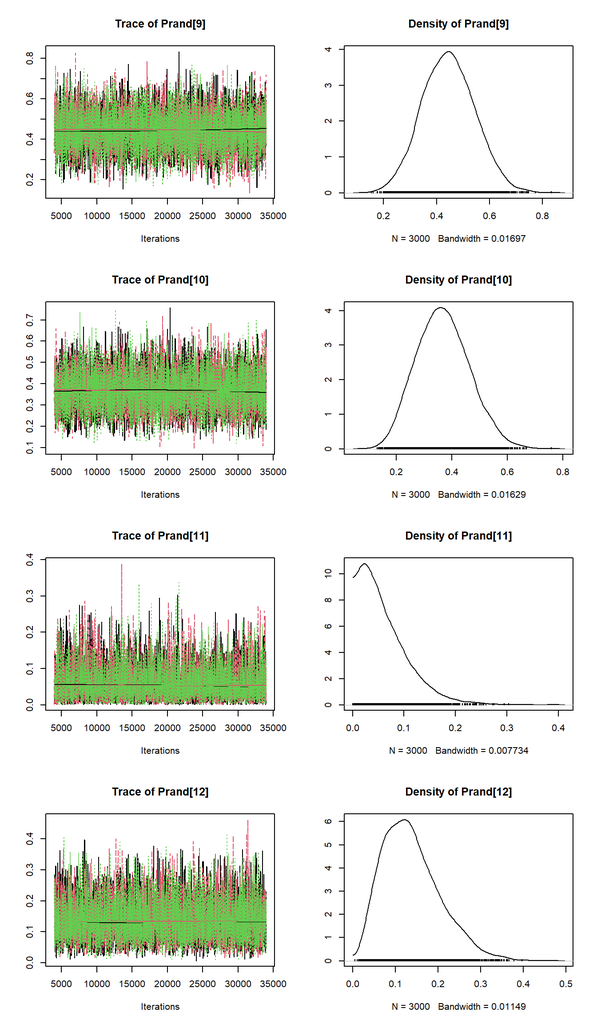

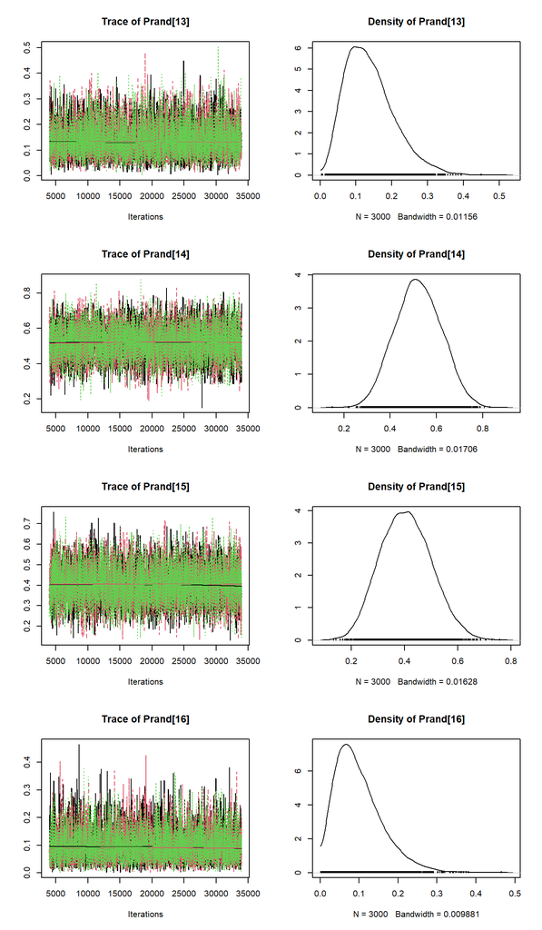

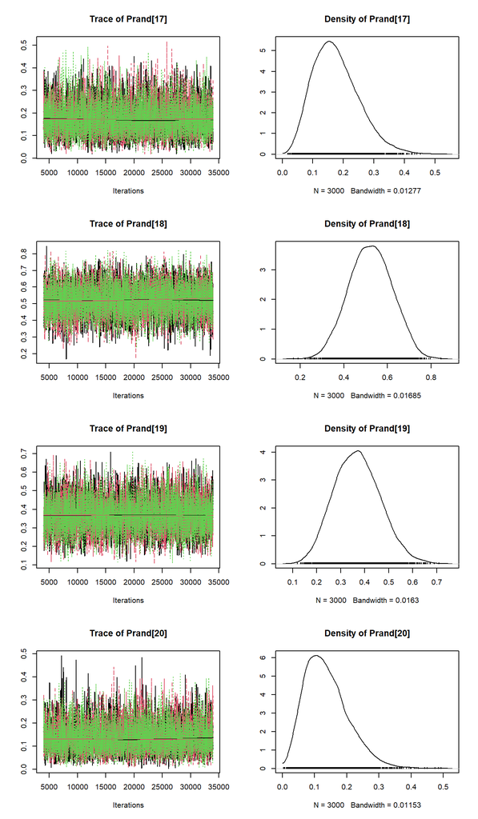

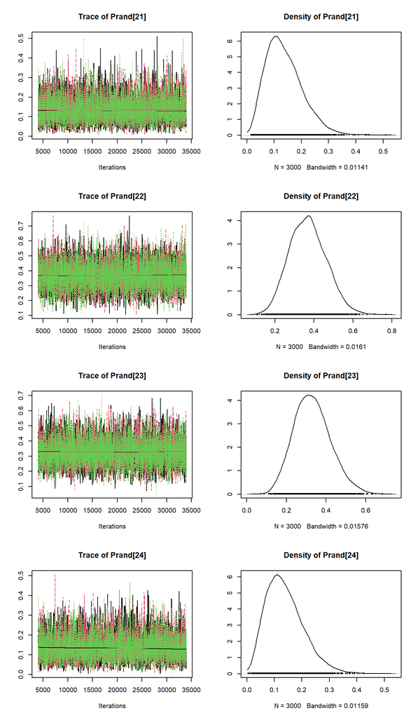

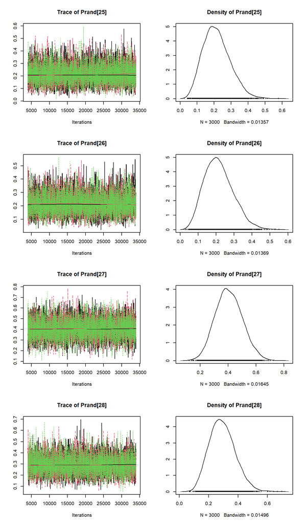

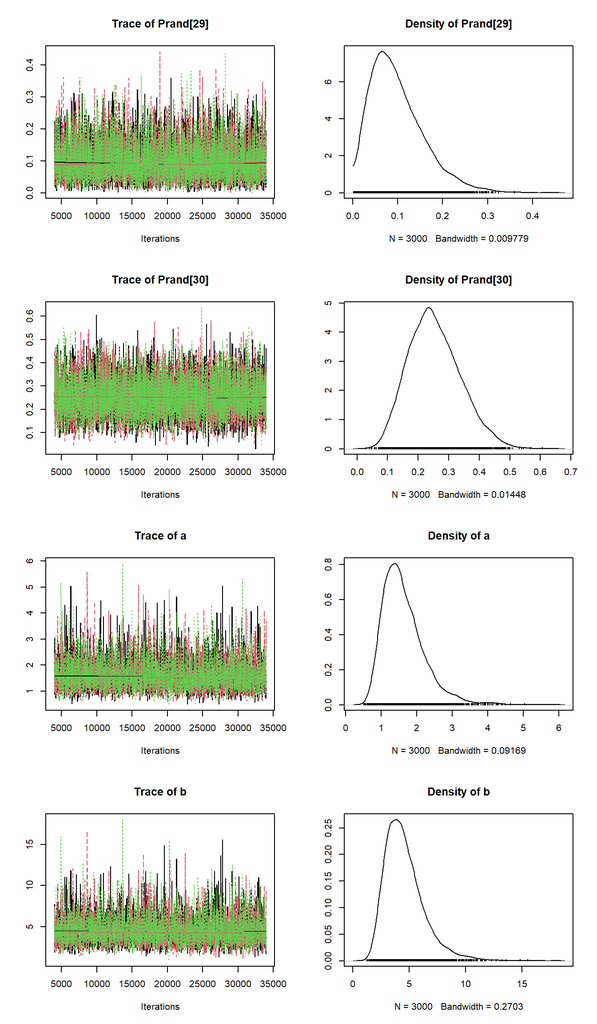

```r
plot(bayesian.fit)
```

```r
summary(bayesian.fit)
```

```
##
## Iterations = 4010:34000
## Thinning interval = 10
## Number of chains = 3
## Sample size per chain = 3000
##
## 1. Empirical mean and standard deviation for each variable,
##    plus standard error of the mean:
##
##              Mean      SD  Naive SE Time-series SE
## Prand[1]  0.36889 0.09422 0.0009931      0.0009798
## Prand[2]  0.56151 0.09867 0.0010401      0.0010549
## Prand[3]  0.06072 0.04838 0.0005100      0.0005571
## Prand[4]  0.33148 0.09063 0.0009553      0.0009673
## Prand[5]  0.21431 0.07908 0.0008335      0.0008430
## Prand[6]  0.32993 0.09122 0.0009616      0.0009534
## Prand[7]  0.09884 0.05919 0.0006239      0.0006463
## Prand[8]  0.13849 0.06761 0.0007127      0.0007009
## Prand[9]  0.44533 0.09892 0.0010427      0.0010489
## Prand[10] 0.36853 0.09495 0.0010008      0.0010104
## Prand[11] 0.06026 0.04752 0.0005009      0.0005382
## Prand[12] 0.13732 0.06698 0.0007060      0.0007205
## Prand[13] 0.13839 0.06775 0.0007141      0.0007178
## Prand[14] 0.52091 0.09943 0.0010481      0.0010763
## Prand[15] 0.40478 0.09491 0.0010005      0.0010005
## Prand[16] 0.09948 0.05969 0.0006292      0.0006338
## Prand[17] 0.17599 0.07443 0.0007845      0.0007779
## Prand[18] 0.52215 0.09819 0.0010350      0.0010677
## Prand[19] 0.36885 0.09502 0.0010016      0.0010146
## Prand[20] 0.13715 0.06721 0.0007085      0.0007085
## Prand[21] 0.13732 0.06653 0.0007013      0.0007013
## Prand[22] 0.36840 0.09382 0.0009890      0.0010044
## Prand[23] 0.33016 0.09188 0.0009685      0.0009772
## Prand[24] 0.13855 0.06757 0.0007123      0.0007123
## Prand[25] 0.21503 0.07909 0.0008337      0.0008356
## Prand[26] 0.21540 0.07980 0.0008412      0.0008333
## Prand[27] 0.40661 0.09585 0.0010103      0.0010103
## Prand[28] 0.29230 0.08716 0.0009188      0.0009070
## Prand[29] 0.09940 0.05947 0.0006268      0.0006538
## Prand[30] 0.25384 0.08438 0.0008895      0.0008745
```

[output cut: 23 more lines]

```
## Prand[18] 0.332966 0.45337 0.52226 0.59007 0.7102
## Prand[19] 0.196281 0.30047 0.36611 0.43236 0.5622
## Prand[20] 0.034426 0.08640 0.12763 0.17649 0.2906
## Prand[21] 0.036186 0.08778 0.12778 0.17713 0.2871
## Prand[22] 0.198224 0.30084 0.36575 0.42995 0.5599
## Prand[23] 0.165192 0.26447 0.32485 0.38892 0.5273
## Prand[24] 0.034772 0.08810 0.12963 0.17930 0.2932
## Prand[25] 0.081773 0.15804 0.20857 0.26521 0.3859
## Prand[26] 0.080811 0.15678 0.20828 0.26584 0.3894
## Prand[27] 0.226518 0.33978 0.40306 0.47086 0.6020
## Prand[28] 0.138741 0.23039 0.28747 0.34949 0.4765
## Prand[29] 0.016349 0.05582 0.08839 0.13219 0.2425
## Prand[30] 0.107659 0.19287 0.24658 0.30835 0.4366
## a         0.798173 1.20876 1.51729 1.92483 3.1013
## b         2.102271 3.33858 4.29034 5.44925 8.8573
```

# Implementing “Data Cloning”, use uniform priors

The key difference is entering the replicated (cloned) data. How do you do that? well, you simply copy the data ‘K’ times. If K=1, the results correspond to a Bayesian analysis, and as K grows large, the resulting posterior converges to a MVNorm whose mean is equal to the MLEs and variance is equal to (1/K)*Inverse(Fisher’s info)

```r
DC.beta.binom <- function(){

  # needs:
  # a vector of counts (Y)
  # the length of this vector (len)
  # the number of binomial trials (ntrials)

  # priors for a and b
  a~dunif(low.prior,high.prior)
  b~dunif(low.prior,high.prior)


    # Random effects model
  for(i in 1:len){
    for(k in 1:K){
      Prand[i,k] ~ dbeta(a,b)
    }
  }

   # Likelihood (conditioned on the random effect)
  for(i in 1:len){
    for(k in 1:K){
      Y[i,k] ~ dbin(Prand[i,k],ntrials)
    }
  }

}
```

Simulating data again, although I don’t think this is necessary since we’ve already simulated this data in the first section of this document.

```r
##### Simulating data:
n <- 30
a <- 2
b <- 5
ntrials <- 20

P <- rbeta(n=n, shape1=a, shape2=b)
YgP <- rbinom(n=n, size=ntrials, prob=P)
```

## Bayesian fit, K = 1

```r
K <- 1
prior.low <- 0
prior.high <- 100
out.parms <- c("a", "b")
Ymat <- matrix(rep(YgP, K), nrow=n,ncol=K, byrow=FALSE)
dc.list <- list(Y=Ymat, len=n, ntrials=ntrials, low.prior=prior.low, high.prior=prior.high, K=K)
bayesian.fit <- jags.fit(dc.list, params=out.parms, model=DC.beta.binom,
                         n.chains=3, n.adapt=3000, n.update=1000, n.iter=30000, thin=10)
summary(bayesian.fit)[[1]]
```

```
##       Mean        SD    Naive SE Time-series SE
## a 1.734350 0.5704692 0.006013273    0.008810521
## b 3.418314 1.1714014 0.012347655    0.017301881
```

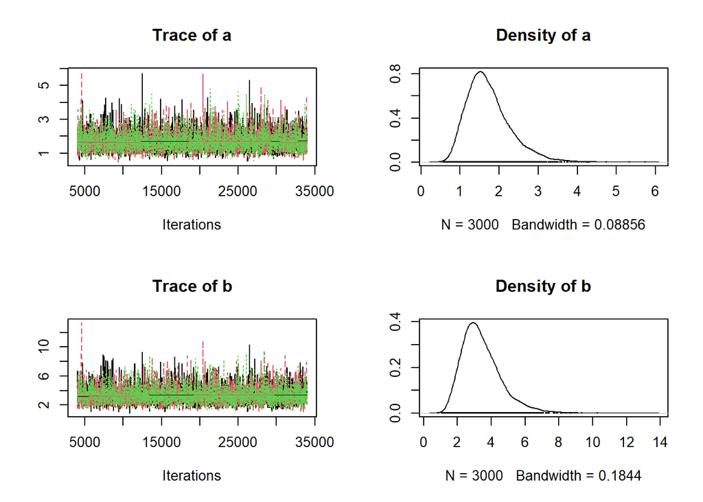

```r
plot(bayesian.fit)
```

```r
Cred.Ints <- apply(bayesian.fit[[1]], 2,FUN=function(x){quantile(x,probs=c(0.025,0.5,0.975))})
```

### STRAIGHT UP NUMERICAL OPTIMIZATION MLE ESTIMATION

```r
myguess <- log(c(1.5,4))
opt.samp <- optim(par=myguess, fn=bbnegllike, method="Nelder-Mead", Yvec=YgP, ntrials=ntrials)
a.hat <- exp(opt.samp$par[1])
b.hat <- exp(opt.samp$par[2])
print(a.hat)
```

```
## [1] 1.402428
```

```r
print(b.hat)
```

```
## [1] 2.725387
```

#—————————————————— ## Data cloning with K=32

```r
K <- 32
prior.low <- 0
prior.high <- 100
out.parms <- c("a", "b")
Ymat <- matrix(rep(YgP, K), nrow=n,ncol=K, byrow=FALSE)
dc.list <- list(Y=Ymat, len=n, ntrials=ntrials, low.prior=prior.low, high.prior=prior.high, K=K)
ml.fit <- jags.fit(dc.list, params=out.parms, model=DC.beta.binom,
                         n.chains=3, n.adapt=4000, n.update=1000, n.iter=50000, thin=10)
summary(ml.fit)[[1]]
```

```
##       Mean         SD     Naive SE Time-series SE
## a 1.410487 0.07745704 0.0006324341   0.0007825732
## b 2.742866 0.15875567 0.0012962346   0.0015651148
```

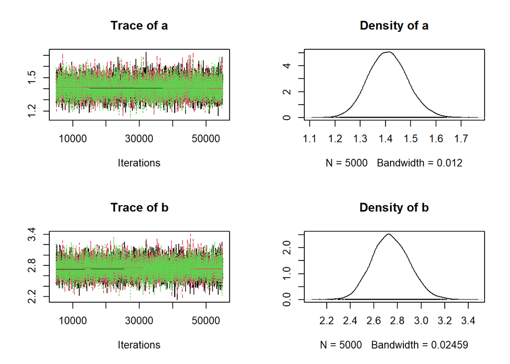

```r
plot(ml.fit)
```

Wald Confidence Intervals

```r
kth.post <- ml.fit[[1]]
mles <- apply(kth.post, 2,mean)
fish.inv <- K*var(kth.post)
alpha <- 0.05
z.alpha.half <- qnorm(p=(1-alpha/2))
a.std.error <- z.alpha.half*sqrt(fish.inv[1,1])
b.std.error <- z.alpha.half*sqrt(fish.inv[2,2])
a.cis <- c(mles[1]-a.std.error,mles[1], mles[1]+a.std.error)
b.cis <- c(mles[2]-b.std.error,mles[2], mles[2]+b.std.error)

CIs.mat <- rbind(a.cis,b.cis);
colnames(CIs.mat) <- c("LCL", "MLE", "UCL")
rownames(CIs.mat) <- c("a","b")
print(CIs.mat) # Compare to
```

```
##         LCL      MLE      UCL
## a 0.5668037 1.408646 2.250488
## b 0.9906886 2.738643 4.486597
```

```r
print(Cred.Ints)
```

```
##              a        b
## 2.5%  0.906774 1.706279
## 50%   1.648148 3.240764
## 97.5% 3.076041 6.228755
```

ASSIDE: TO UNDERSTAND THE REST, I NEED MONTE CARLO INTEGRATION

Numerical Integration example

##### h(x)dx = h(x) (f(x)/f(x)) dx

##### == E[(h(x)/f(x))] with respect of the distribution f(x)

$$\int h(x)dx = \int h(x) \frac{f(x)}{f(x)} dx$$
$$= \int \frac{h(x)}{f(x)}\times f(x) dx$$
$$== E\left[\frac{h(x)}{f(x)} \right] \text{with respect of the distribution} f(x)$$

# Example of Monte Carlo integration

# Say I need to compute Var(Y), where Y~exp(lambda=3).

# Var(Y) = I = int_{0}^{Infty} (y-(1/lambda))^2 *lambda*exp(-y*lambda) dy

```r
# First, set the value of lambda
lam <- 3
nsamps <- 1000000


# Now sample from another distribution with support in (0,Infty), say an exp(theta=4)
theta <- 4
y.samps <- rexp(n=nsamps, rate=theta)


mc.integrand <- (((y.samps-(1/lam))^2)*lam*exp(-y.samps*lam))/(theta*exp(-y.samps*theta))

real.var <- 1/(lam^2)
real.var
```

```
## [1] 0.1111111
```

```r
mean(mc.integrand)# LLN
```

```
## [1] 0.1116897
```

#—————————————————————

Now, obtaining MCMC samples from the distribution of the hidden process given the observations. If $f(y|x)$ is the likelihood and $g(x;theta)$ is the hidden process, then this posterior distribution is $h(x|y;theta) \propto f(y|x)g(x;theta)$ which we can sample from using a simple MCMC run.

```r
Kalman.beta.binom <- function(){

  # needs:
  # a vector of counts (Y)
  # the length of this vector (len)
  # the number of binomial trials (ntrials)
  # The values of a and b = the MLES

  # Random effects model
  for(i in 1:len){
      Prand[i] ~ dbeta(a,b)
  }

  # Likelihood (conditioned on the random effect)
  for(i in 1:len){
      Y[i] ~ dbin(Prand[i],ntrials)
  }

}
```

```r
out.parms <- c("Prand")
kalman.list <- list(Y=YgP, len=n, ntrials=ntrials, a=mles[1], b=mles[2])
kalman.samps <- jags.fit(kalman.list, params=out.parms, model=Kalman.beta.binom,
                   n.chains=3, n.adapt=4000, n.update=1000, n.iter=50000, thin=10)
summary(kalman.samps)
```

```
##
## Iterations = 5010:55000
## Thinning interval = 10
## Number of chains = 3
## Sample size per chain = 5000
##
## 1. Empirical mean and standard deviation for each variable,
##    plus standard error of the mean:
##
##              Mean      SD  Naive SE Time-series SE
## Prand[1]  0.47352 0.09987 0.0008154      0.0008130
## Prand[2]  0.18129 0.07668 0.0006261      0.0006264
## Prand[3]  0.38873 0.09626 0.0007859      0.0007672
## Prand[4]  0.14137 0.06991 0.0005708      0.0005708
## Prand[5]  0.22286 0.08234 0.0006723      0.0006674
## Prand[6]  0.39016 0.09715 0.0007932      0.0007979
## Prand[7]  0.51442 0.10088 0.0008237      0.0008236
## Prand[8]  0.76286 0.08558 0.0006988      0.0006832
## Prand[9]  0.14104 0.06922 0.0005652      0.0005575
## Prand[10] 0.26557 0.08792 0.0007178      0.0007182
## Prand[11] 0.55360 0.09866 0.0008056      0.0007793
## Prand[12] 0.63909 0.09534 0.0007784      0.0007725
## Prand[13] 0.30734 0.09200 0.0007512      0.0007512
## Prand[14] 0.18148 0.07721 0.0006305      0.0006482
## Prand[15] 0.18135 0.07680 0.0006271      0.0006271
## Prand[16] 0.38915 0.09759 0.0007968      0.0007966
## Prand[17] 0.72139 0.08982 0.0007334      0.0007334
## Prand[18] 0.14107 0.06952 0.0005676      0.0005677
## Prand[19] 0.22325 0.08232 0.0006721      0.0006674
## Prand[20] 0.18301 0.07688 0.0006277      0.0006277
## Prand[21] 0.43033 0.09850 0.0008043      0.0007903
## Prand[22] 0.30667 0.09140 0.0007463      0.0007653
## Prand[23] 0.18213 0.07655 0.0006250      0.0006250
## Prand[24] 0.59766 0.09812 0.0008011      0.0008008
## Prand[25] 0.30641 0.09282 0.0007579      0.0007578
## Prand[26] 0.05789 0.04672 0.0003815      0.0003843
## Prand[27] 0.35007 0.09543 0.0007792      0.0007855
## Prand[28] 0.05795 0.04700 0.0003837      0.0003837
## Prand[29] 0.63785 0.09587 0.0007827      0.0007774
## Prand[30] 0.22414 0.08283 0.0006763      0.0006716
```

[output cut: 19 more lines]

```
## Prand[16] 0.207692 0.32064 0.38749 0.45564 0.5866
## Prand[17] 0.531919 0.66321 0.72701 0.78636 0.8792
## Prand[18] 0.036585 0.08919 0.13079 0.18265 0.3016
## Prand[19] 0.084539 0.16246 0.21687 0.27625 0.4027
## Prand[20] 0.059139 0.12617 0.17403 0.23075 0.3552
## Prand[21] 0.245155 0.36161 0.42893 0.49691 0.6246
## Prand[22] 0.144455 0.24085 0.30161 0.36755 0.4955
## Prand[23] 0.060437 0.12523 0.17310 0.22890 0.3554
## Prand[24] 0.399107 0.53203 0.60090 0.66667 0.7820
## Prand[25] 0.142690 0.23898 0.30171 0.36828 0.4988
## Prand[26] 0.003630 0.02323 0.04549 0.08014 0.1780
## Prand[27] 0.177930 0.28195 0.34569 0.41358 0.5479
## Prand[28] 0.003712 0.02308 0.04610 0.08011 0.1811
## Prand[29] 0.441771 0.57424 0.64235 0.70637 0.8141
## Prand[30] 0.086011 0.16319 0.21617 0.27717 0.4071
```

[figure not shown]

[figure not shown]

[figure not shown]

[figure not shown]

[figure not shown]

[figure not shown]

[figure not shown]

[figure not shown]

```r
plot(kalman.samps)
```